# Experiments with a Single Factor: The Analysis of Variance

When factors are used in linear models then there’s some flexibility in how we model the factor. By default, R uses a function `contr.treatment` to encode unordered factors and `contr.poly` to encode ordered factors. If a factor has $k$ levels then `contr.treatment` function will encode the last $k-1$ as indicator functions. This causes the first level of the factor to be aliased into the intercept term in the model and the remaining coefficients represent the difference from this mean. If we want the levels of the factor to be encoded in such a way that the sum of their coefficients is zero and the intercept represents the overall mean then we have to use `contr.sum`. The following will set the default for unordered factor to be `contr.sum` and leave the ordered factor behavior as the default.

```r
options(contrasts=c('unordered'='contr.sum', 'ordered'='contr.poly'))
```

Note that this setting only affects the effect estimates - things like ANOVA table sums of squares shouldn’t be affected.

# Example 3.1 - The Plasma Etching Experiment

The plasma etching experiment of Table 3.1 relates the RF power to the depth of the etching. At each of the 4 power levels there were 5 observations. The structure of the `data.frame` is given below.

```r
str(Table3.1)
# 'data.frame': 20 obs. of  2 variables:
#  $ Power      : Factor w/ 4 levels "160","180","200",..: 1 1 1 1 1 2 2 2 2 2 ...
#  $ Observation: num  575 542 530 539 570 565 593 590 579 610 ...
```

Fitting the ANOVA model we find that we can reject the null hypothesis that all of the power levels have the same average etch amount.

```r
summary(aov(Observation ~ Power, data=Table3.1))
#             Df Sum Sq Mean Sq F value   Pr(>F)
# Power        3  66871   22290    66.8 2.88e-09 ***
# Residuals   16   5339     334
# ---
# Signif. codes:  0 '***' 0.001 '**' 0.01 '*' 0.05 '.' 0.1 ' ' 1
```

Compare this result to Table 3.4 in Example 3.1. To get the effect estimates in Example 3.3 we have to do a little extra work.

```r
model <- lm(Observation ~ Power, data=Table3.1)
summary(model)
#
# Call:
# lm(formula = Observation ~ Power, data = Table3.1)
#
# Residuals:
#    Min     1Q Median     3Q    Max
#  -25.4  -13.0    2.8   13.2   25.6
#
# Coefficients:
#             Estimate Std. Error t value Pr(>|t|)
# (Intercept)  617.750      4.085 151.234  < 2e-16 ***
# Power1       -66.550      7.075  -9.406 6.39e-08 ***
# Power2       -30.350      7.075  -4.290 0.000563 ***
# Power3         7.650      7.075   1.081 0.295602
# ---
# Signif. codes:  0 '***' 0.001 '**' 0.01 '*' 0.05 '.' 0.1 ' ' 1
#
# Residual standard error: 18.27 on 16 degrees of freedom
# Multiple R-squared:  0.9261,  Adjusted R-squared:  0.9122
# F-statistic:  66.8 on 3 and 16 DF,  p-value: 2.883e-09
```

Since the sum of the coefficients for the `Power` factor is zero we know the `Power4` coefficient is 89.25.

To check the model adequacy we can generate the normal probability plot of the residuals from the model.

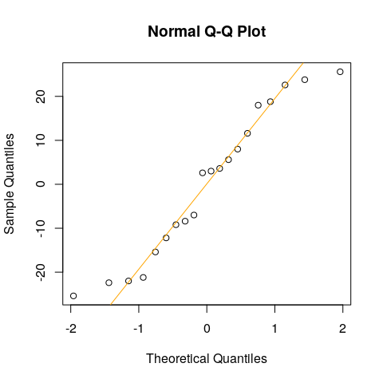

```r
qqnorm(resid(model))
qqline(resid(model), col='orange')
```

The normal probability plot doesn’t show any strong signs of non-normality. Next, let’s examine the residual-by-run-order plot to look for patterns that would indicate a lack of independence and the predicted-versus-residual plot to check for equality of variance.

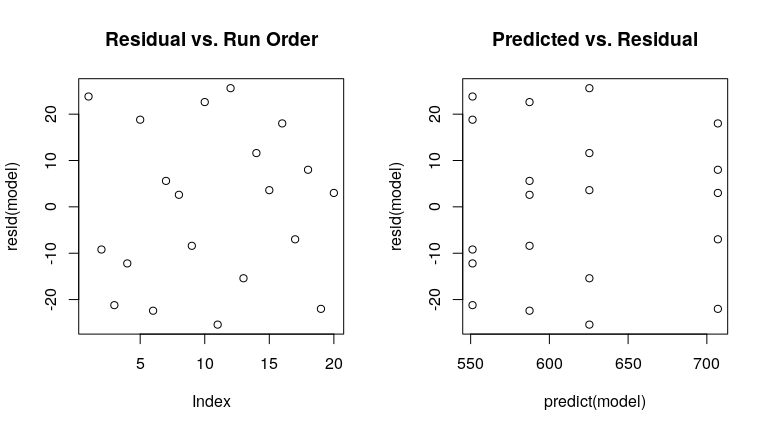

```r
op <- par(mfrow=c(1, 2))
plot(resid(model), main='Residual vs. Run Order')
plot(x=predict(model), y=resid(model), main='Predicted vs. Residual')
```

```r
par(op)
```

Neither plot seems to show strong signs of trouble. We can also perform a formal test for equality of variance. Bartlett’s test, described in Section 3.4, tests
$$H_0: \sigma_1^2 = \sigma_2^2 = \ldots = \sigma_a^2
\quad\text{vs.}\quad
H_A: \text{above not true for at leas one}~\sigma_i^2~.$$
This is easy to do in R.

```r
bartlett.test(Observation ~ Power, data=Table3.1)
#
#   Bartlett test of homogeneity of variances
#
# data:  Observation by Power
# Bartlett's K-squared = 0.43349, df = 3, p-value = 0.9332
```

Bartlett’s test fails to reject the null hypothesis. We find no strong evidence that the model is an inadequate description of the data.

# Example 3.5 and Variance Stabilizing Transforms

In Example 3.5 an engineer is investigating if there’s a difference between the 4 methods of estimating flood flow frequency. Note that here, estimation method is coded as 1, 2, 3, or 4. It’s important to check that these are a factor so that R doesn’t try to treat 4 as twice the estimation method as 2.

```r
str(Example3.5)
# 'data.frame': 24 obs. of  2 variables:
#  $ EstimationMethod: Factor w/ 4 levels "1","2","3","4": 1 1 1 1 1 1 2 2 2 2 ...
#  $ Observation     : num  0.34 0.12 1.23 0.7 1.75 0.12 0.91 2.94 2.14 2.36 ...
```

Having verified `EstimationMethod` is a factor, let’s construct the ANOVA table as in Table 3.8.

```r
model <- aov(Observation ~ EstimationMethod, data=Example3.5)
summary(model)
#                  Df Sum Sq Mean Sq F value   Pr(>F)
# EstimationMethod  3  708.3   236.1   76.07 4.11e-11 ***
# Residuals        20   62.1     3.1
# ---
# Signif. codes:  0 '***' 0.001 '**' 0.01 '*' 0.05 '.' 0.1 ' ' 1
```

The following diagnostic plot of predicted-versus-residual suggests that the model is not appropriate.

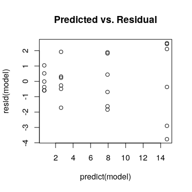

```r
plot(predict(model), resid(model), main='Predicted vs. Residual')
```

As suggested in the text, we apply a $y^\star = \sqrt{y}$ transform and refit the model, achieving Table 3.10.

```r
y <- sqrt(Example3.5$Observation)
model <- aov(y ~ EstimationMethod, data=Example3.5)
summary(model)
#                  Df Sum Sq Mean Sq F value  Pr(>F)
# EstimationMethod  3  32.68  10.895   81.05 2.3e-11 ***
# Residuals        20   2.69   0.134
# ---
# Signif. codes:  0 '***' 0.001 '**' 0.01 '*' 0.05 '.' 0.1 ' ' 1
```

The new predicted versus residual plot looks much better.

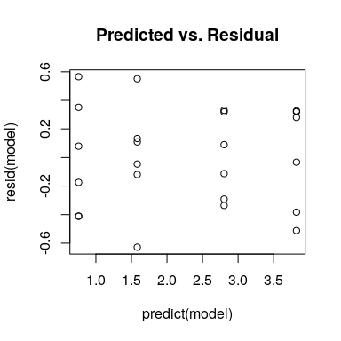

```r
plot(predict(model), resid(model), main='Predicted vs. Residual')
```

Even though the conclusions drawn from the untransformed data are the same as with the transformed data, having validated our model assumptions means we can put more trust in our results.

# Regression Model

Section 3.5.1 suggests using a regression model to fit the etch data of Table 3.1. To do this, first we convert `Power` to a numeric vector `x`. Next, we fit the linear and quadratic models. The symbol `I(x^2)` tells R that `x^2` is how you want to transform `x` and include it in the model. If we left the `I` part off the result would be that R would effectively treat it as a second `x` term in the formula and ignore it.

```r
x <- as.numeric(as.character(Table3.1$Power))
linear.model <- lm(Observation ~ x, data=Table3.1)
quadratic.model <- lm(Observation ~ x + I(x^2), data=Table3.1)
```

Next let’s plot the linear versus the quadratic fits.

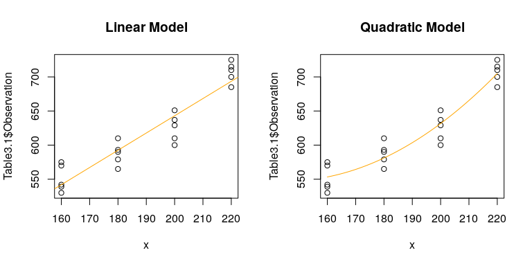

```r
op <- par(mfrow=c(1,2))
plot(x, Table3.1$Observation, main='Linear Model')
abline(a=coef(linear.model)[1], b=coef(linear.model)[2], col='orange')
plot(x, Table3.1$Observation, main='Quadratic Model')
u <- seq(from=160, to=220, length.out=100)
v <- cbind(rep(1, length(u)), u, u^2) %*% coef(quadratic.model)
lines(u, v, col='orange')
```

```r
par(op)
```

Visual inspection suggests that the quadratic model is a better fit for the data. This model lets us estimate mean etch depth at power levels between 160 and 220, which would not be possible using the original ANOVA model.

# Contrasts

Recall the ANOVA model for the plasma etching experiment.

```r
model <- aov(Observation ~ Power, data=Table3.1)
summary(model)
#             Df Sum Sq Mean Sq F value   Pr(>F)
# Power        3  66871   22290    66.8 2.88e-09 ***
# Residuals   16   5339     334
# ---
# Signif. codes:  0 '***' 0.001 '**' 0.01 '*' 0.05 '.' 0.1 ' ' 1
```

One way to calculate individual contrasts is to use the [`emmeans`](https://cran.r-project.org/package=emmeans) package (Lenth et al. 2019). Here we’ll create an object and then derive the contrasts from it.

```r
library(emmeans)
emmodel <- emmeans(model,   ~ Power)
contrast(emmodel, list(
    'C1'=c(1, -1, 0, 0),
    'C2'=c(1, 1, -1, -1),
    'C3'=c(0, 0, 1, -1)
))
#  contrast estimate   SE df t.ratio p.value
#  C1          -36.2 11.6 16  -3.133 0.0064
#  C2         -193.8 16.3 16 -11.861 <.0001
#  C3          -81.6 11.6 16  -7.063 <.0001
```

These contrasts match those given in Example 3.6. We can also do all pairwise comparisons of the `Power` factor using the Tukey adjustment of Example 3.7.

```r
pairs(emmodel, adjust="tukey")
#  contrast  estimate   SE df t.ratio p.value
#  160 - 180    -36.2 11.6 16  -3.133 0.0294
#  160 - 200    -74.2 11.6 16  -6.422 <.0001
#  160 - 220   -155.8 11.6 16 -13.485 <.0001
#  180 - 200    -38.0 11.6 16  -3.289 0.0216
#  180 - 220   -119.6 11.6 16 -10.352 <.0001
#  200 - 220    -81.6 11.6 16  -7.063 <.0001
#
# P value adjustment: tukey method for comparing a family of 4 estimates
```

Both Fisher’s LSD and Dunnett’s test can be run by comparing the derived critical value to the estimate given above.

# Determining Sample Size

As in Chapter 2 we will use the `pwr` package to calculate power/sample size. For the single factor ANOVA, we wish to calculate an effect size $f$ to use in our power calculation. Let there be $a$ levels each with $n$ samples for a total of $N = an$ samples overall. Let $\mu_i$ be the mean of level $i$, $\mu$ the overall mean (mean of all means), and let $\sigma$ be the standard deviation. The effect size $f$ is
$$f = \frac{1}{\sigma} \sqrt{\frac{1}{a}
\sum_{i=1}^k (\mu_i - \mu)^2
}$$
In Example 3.1, the standard deviation is 25 with prospective means 575, 600, 650, and 675. Thus, if we have 3 samples at each mean and our test is to have $\alpha =0.01$ then the power would be

```r
library(pwr)
w <- c(575, 600, 650, 675)
a <- length(w)
sigma <- 25
f <- sqrt((1/a)* sum((w - mean(w))^2)) / sigma
pwr.anova.test(k=4, f=f, n=3, sig.level=0.01)
#
#      Balanced one-way analysis of variance power calculation
#
#               k = 4
#               n = 3
#               f = 1.581139
#       sig.level = 0.01
#           power = 0.7534019
#
# NOTE: n is number in each group
```

so about 75%. We can construct the power curve easily:

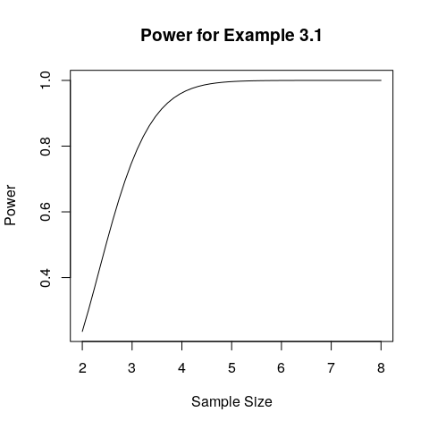

```r
library(pwr)
n <- seq(from=2, to=8, length.out=50)
y <- pwr.anova.test(k=4, f=f, sig.level=0.01, n=n)$power
plot(n, y, type='l',
     main='Power for Example 3.1',
     xlab='Sample Size',
     ylab='Power')
```

According to the plot, to get 90% power would require a sample size of 4 at each group (16 overall). If we wish for 90% power we can get that directly.

```r
pwr.anova.test(k=4, f=f, sig.level=0.01, power=0.9)
#
#      Balanced one-way analysis of variance power calculation
#
#               k = 4
#               n = 3.520261
#               f = 1.581139
#       sig.level = 0.01
#           power = 0.9
#
# NOTE: n is number in each group
```

Rounding up, we’d require $n=4$ samples at each level of `Power`.

# Chocolate Consumption Experiment of Section 3.8.1

Consider the experiment described in Section 3.8.1 where three different types of chocolate were given to subjects and then the antioxidant capacity of their blood plasma was measured. A boxplot of the data is presented below.

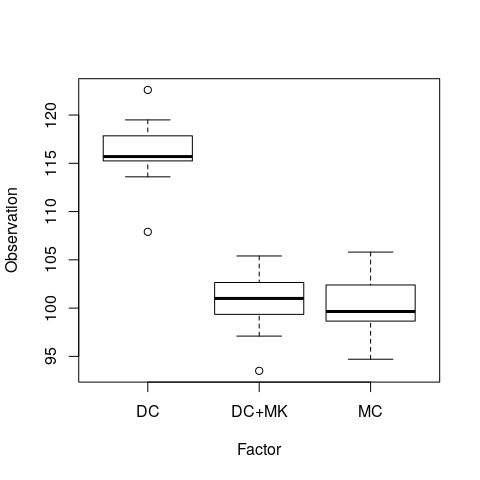

```r
boxplot(Observation ~ Factor, data=Table3.12)
```

Next, we fit an ANOVA model and look for the general significance test.

```r
summary(aov(Observation ~ Factor, data=Table3.12))
#             Df Sum Sq Mean Sq F value   Pr(>F)
# Factor       2 1952.6   976.3   93.58 2.52e-14 ***
# Residuals   33  344.3    10.4
# ---
# Signif. codes:  0 '***' 0.001 '**' 0.01 '*' 0.05 '.' 0.1 ' ' 1
```

This indicates that the chocolate concoctions had differing mean effects on antioxidant levels. To estimate the individual effects we use a linear model without an intercept.

```r
means.model <- lm(Observation ~ Factor - 1, data=Table3.12)
print(summary(means.model))
#
# Call:
# lm(formula = Observation ~ Factor - 1, data = Table3.12)
#
# Residuals:
#     Min      1Q  Median      3Q     Max
# -8.1583 -1.4083 -0.3583  1.9375  6.5417
#
# Coefficients:
#             Estimate Std. Error t value Pr(>|t|)
# FactorDC    116.0583     0.9324   124.5   <2e-16 ***
# FactorDC+MK 100.7000     0.9324   108.0   <2e-16 ***
# FactorMC    100.1833     0.9324   107.4   <2e-16 ***
# ---
# Signif. codes:  0 '***' 0.001 '**' 0.01 '*' 0.05 '.' 0.1 ' ' 1
#
# Residual standard error: 3.23 on 33 degrees of freedom
# Multiple R-squared:  0.9991,  Adjusted R-squared:  0.9991
# F-statistic: 1.29e+04 on 3 and 33 DF,  p-value: < 2.2e-16
```

Next, we generate confidence intervals for each chocolate level.

```r
confint(means.model)
#                 2.5 %   97.5 %
# FactorDC    114.16125 117.9554
# FactorDC+MK  98.80292 102.5971
# FactorMC     98.28625 102.0804
```

Next, we’ll look at all pairwise comparisons (without making any adjustment for multiple comparisons).

```r
pairwise.model <- pairs(emmeans(aov(Observation ~ Factor, data=Table3.12), ~Factor), adjust='none')
print(pairwise.model)
#  contrast   estimate   SE df t.ratio p.value
#  DC - DC+MK   15.358 1.32 33 11.647  <.0001
#  DC - MC      15.875 1.32 33 12.039  <.0001
#  DC+MK - MC    0.517 1.32 33  0.392  0.6977
```

We follow the point estimates with confidence intervals for the pairwise differences.

```r
confint(pairwise.model)
#  contrast   estimate   SE df lower.CL upper.CL
#  DC - DC+MK   15.358 1.32 33    12.68     18.0
#  DC - MC      15.875 1.32 33    13.19     18.6
#  DC+MK - MC    0.517 1.32 33    -2.17      3.2
#
# Confidence level used: 0.95
```

This is strong evidence that `DC` produces a larger effect than `DC+MK` and `MC`. Finally, let’s produce the diagnostic plots to ensure our model is adequate.

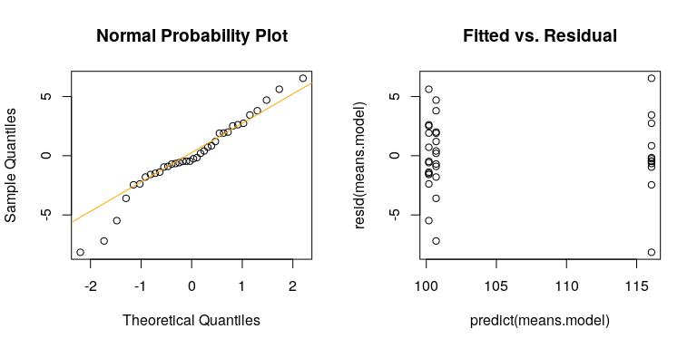

```r
op <- par(mfrow=c(1,2))
qqnorm(resid(means.model), main='Normal Probability Plot')
qqline(resid(means.model), col='orange')
plot(x=predict(means.model), y=resid(means.model), main='Fitted vs. Residual')
```

```r
par(op)
```

Both diagnostic plots fail to show any strong evidence of deviation from our modelling assumptions. This provides us with enough information to draw the same conclusion as the text - dark chocolate “DC” results in a higher mean blood antioxidant capacity than the other two chocolates.

# End-Aisle Experiment of Section 3.8.2

The end-aisle experiment of Section 3.8.2 compares three different display designs in terms of the percent increase in sales. Here, the design is encoded using the numbers 1, 2, and 3 so we must be careful that those are recorded as factors.

```r
str(Table3.14)
# 'data.frame': 15 obs. of  2 variables:
#  $ DisplayDesign: Factor w/ 3 levels "1","2","3": 1 2 3 1 2 3 1 2 3 1 ...
#  $ Observations : num  5.43 6.24 8.79 5.71 6.71 9.2 6.22 5.98 7.9 6.01 ...
```

A visual inspection of the distributions of sales increases suggests that `DisplayDesign` has an effect.

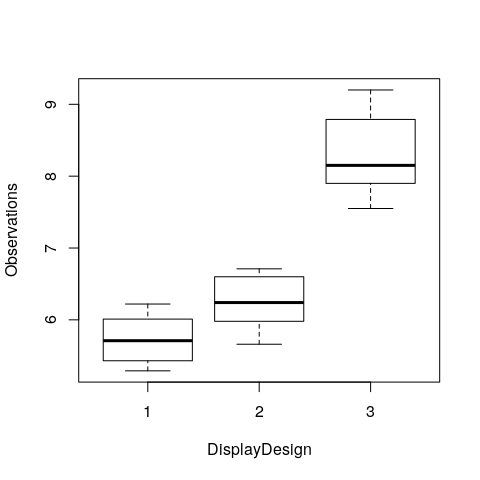

```r
boxplot(Observations ~ DisplayDesign, data=Table3.14)
```

Let’s start by running the ANOVA general $F$-test.

```r
model <- aov(Observations ~ DisplayDesign, data=Table3.14)
summary(model)
#               Df Sum Sq Mean Sq F value   Pr(>F)
# DisplayDesign  2  18.78   9.392   35.77 8.78e-06 ***
# Residuals     12   3.15   0.263
# ---
# Signif. codes:  0 '***' 0.001 '**' 0.01 '*' 0.05 '.' 0.1 ' ' 1
```

```r
means.model <- lm(Observations ~ DisplayDesign - 1, data=Table3.14)
summary(means.model)
#
# Call:
# lm(formula = Observations ~ DisplayDesign - 1, data = Table3.14)
#
# Residuals:
#    Min     1Q Median     3Q    Max
# -0.768 -0.360 -0.022  0.417  0.882
#
# Coefficients:
#                Estimate Std. Error t value Pr(>|t|)
# DisplayDesign1   5.7320     0.2291   25.02 1.01e-11 ***
# DisplayDesign2   6.2380     0.2291   27.22 3.72e-12 ***
# DisplayDesign3   8.3180     0.2291   36.30 1.22e-13 ***
# ---
# Signif. codes:  0 '***' 0.001 '**' 0.01 '*' 0.05 '.' 0.1 ' ' 1
#
# Residual standard error: 0.5124 on 12 degrees of freedom
# Multiple R-squared:  0.9955,  Adjusted R-squared:  0.9944
# F-statistic: 894.8 on 3 and 12 DF,  p-value: 2.273e-14
```

Then, we can construct the confidence intervals for the means with `confint`

```r
confint(means.model)
#                   2.5 %   97.5 %
# DisplayDesign1 5.232736 6.231264
# DisplayDesign2 5.738736 6.737264
# DisplayDesign3 7.818736 8.817264
```

Alternatively, we could use the `emmeans` package to do this from the effects model. We indicate that we want the means with respect to `DisplayDesign`.

```r
ls.model <- emmeans(model, ~DisplayDesign)
print(ls.model)
#  DisplayDesign emmean    SE df lower.CL upper.CL
#  1               5.73 0.229 12     5.23     6.23
#  2               6.24 0.229 12     5.74     6.74
#  3               8.32 0.229 12     7.82     8.82
#
# Confidence level used: 0.95
```

Next, we construct the confidence intervals.

```r
confint(ls.model)
#  DisplayDesign emmean    SE df lower.CL upper.CL
#  1               5.73 0.229 12     5.23     6.23
#  2               6.24 0.229 12     5.74     6.74
#  3               8.32 0.229 12     7.82     8.82
#
# Confidence level used: 0.95
```

Both methods are presented because the cell means model is often easier but the `emmeans` package will be of more use as we go forward. Note that, in constructing 95% confidence intervals, it appears that design 3’s confidence interval is disjoint from those from designs 1 and 2. Looking at all pairwise comparisons, it appears that display 3 produces the largest mean increase in sales.

```r
pairwise.model <- pairs(ls.model, adjust='none')
print(pairwise.model)
#  contrast estimate    SE df t.ratio p.value
#  1 - 2      -0.506 0.324 12 -1.561  0.1444
#  1 - 3      -2.586 0.324 12 -7.980  <.0001
#  2 - 3      -2.080 0.324 12 -6.419  <.0001
```

We can also construct confidence intervals on the pairwise differences.

```r
confint(pairwise.model)
#  contrast estimate    SE df lower.CL upper.CL
#  1 - 2      -0.506 0.324 12    -1.21     0.20
#  1 - 3      -2.586 0.324 12    -3.29    -1.88
#  2 - 3      -2.080 0.324 12    -2.79    -1.37
#
# Confidence level used: 0.95
```

Next, let’s examine the diagnostic plots.

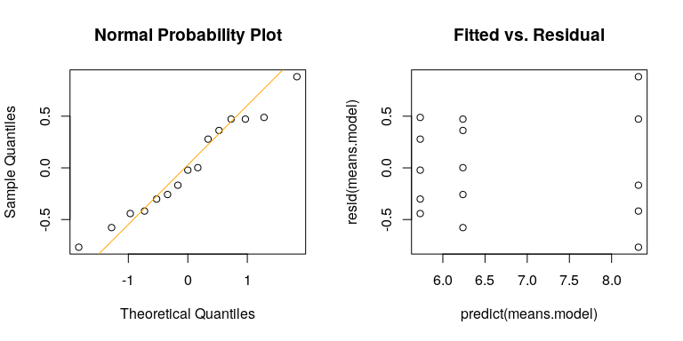

```r
op <- par(mfrow=c(1,2))
qqnorm(resid(means.model), main='Normal Probability Plot')
qqline(resid(means.model), col='orange')
plot(x=predict(means.model), y=resid(means.model), main='Fitted vs. Residual')
```

```r
par(op)
```

There may be a slight increase in variance displayed by the fitted versus residual plots, but no strong evidence of model misspecification.

# Smelting Experiment of Section 3.8.3

The aluminum smelting experiment of Section 3.8.3 describes 4 different ratio control algorithms governing the introduction of alumina to a cell where a response related to cell voltage was recorded. Here, we’re going to model the standard deviation of cell voltage to determine which algorithm is most consistent. First, let’s check that `RatioControlAlgorithm` is a factor.

```r
str(Table3.16)
# 'data.frame': 24 obs. of  3 variables:
#  $ RatioControlAlgorithm: Factor w/ 4 levels "1","2","3","4": 1 1 1 1 1 1 2 2 2 2 ...
#  $ AvgVoltage           : num  4.93 4.86 4.75 4.95 4.79 4.88 4.85 4.91 4.79 4.85 ...
#  $ StDevVoltage         : num  0.05 0.04 0.05 0.06 0.03 0.05 0.04 0.02 0.03 0.05 ...
```

As suggested by the text, we apply the negative log transform to the `StDevVoltage`.

```r
y <- -log(Table3.16$StDevVoltage)
summary(aov(y ~ RatioControlAlgorithm, data=Table3.16))
#                       Df Sum Sq Mean Sq F value   Pr(>F)
# RatioControlAlgorithm  3  6.166  2.0554   21.96 1.54e-06 ***
# Residuals             20  1.872  0.0936
# ---
# Signif. codes:  0 '***' 0.001 '**' 0.01 '*' 0.05 '.' 0.1 ' ' 1
```

A quick visual inspection using boxplots strongly suggests that algorithm 3 produces the largest noise, whereas the others all appear about the same.

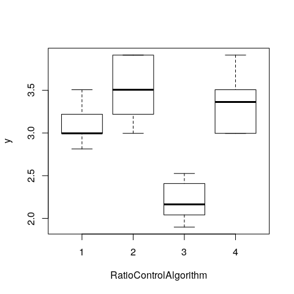

```r
boxplot(y ~ RatioControlAlgorithm, data=Table3.16)
```

# Random Effects Model of Section 3.9 (Example 3.10)

For the loom experiment of Section 3.9 we wish to model the looms as a population, and hence wish to use a random effects model. We can get the ANOVA values for balanced designs using the `Error` term and the normal `aov` function.

```r
model <- aov(Strength ~ Error(Looms), data=Example3.10)
summary(model)
#
# Error: Looms
#           Df Sum Sq Mean Sq F value Pr(>F)
# Residuals  3  89.19   29.73
#
# Error: Within
#           Df Sum Sq Mean Sq F value Pr(>F)
# Residuals 12  22.75   1.896
```

We have to manually construct the mean square errors, $F$-statistic, and $p$-value. The other way is using the `lme4` package (Bates et al. 2019) and the `lmerTest` package (Kuznetsova, Brockhoff, and Christensen 2019) for fitting random and mixed effects. In `lme4`, to indicate a random intercept for each level of loom we use `(1|Looms)` in the formula as follows.

```r
library(lme4)
library(lmerTest)

model <- lmer(
    Strength ~ (1|Looms),
    data=Example3.10,
    REML=TRUE
)
print(summary(model))
# Linear mixed model fit by REML. t-tests use Satterthwaite's method [
# lmerModLmerTest]
# Formula: Strength ~ (1 | Looms)
#    Data: Example3.10
#
# REML criterion at convergence: 63.2
#
# Scaled residuals:
#      Min       1Q   Median       3Q      Max
# -1.38018 -0.57260 -0.04342  0.82574  1.52491
#
# Random effects:
#  Groups   Name        Variance Std.Dev.
#  Looms    (Intercept) 6.958    2.638
#  Residual             1.896    1.377
# Number of obs: 16, groups:  Looms, 4
#
# Fixed effects:
#             Estimate Std. Error     df t value Pr(>|t|)
# (Intercept)   95.438      1.363  3.000   70.01 6.42e-06 ***
# ---
# Signif. codes:  0 '***' 0.001 '**' 0.01 '*' 0.05 '.' 0.1 ' ' 1
print(rand(model))
# ANOVA-like table for random-effects: Single term deletions
#
# Model:
# Strength ~ (1 | Looms)
#             npar  logLik    AIC    LRT Df Pr(>Chisq)
# <none>         3 -31.597 69.193
# (1 | Looms)    2 -37.745 79.489 12.296  1  0.0004539 ***
# ---
# Signif. codes:  0 '***' 0.001 '**' 0.01 '*' 0.05 '.' 0.1 ' ' 1
```

This matches the JMP output of Table 3.20. We can generate confidence intervals for the variance components easily.

```r
confint(model, oldNames=FALSE)
#                           2.5 %    97.5 %
# sd_(Intercept)|Looms  1.1293759  5.748927
# sigma                 0.9672533  2.184005
# (Intercept)          92.4393299 98.435668
```

Above, the confidence intervals for the standard deviations differ from JMP in that these are based on the profile likelihood.

# Kruskal-Wallis Test of Section 3.11

Section 3.11 describes the non-parametric Kruskal-Wallis test. This test doesn’t assume normality, and is very easy to use in R. Here, we run the test against the plasma etch experiment data of Table 3.1.

```r
kruskal.test(Observation ~ Power, data=Table3.1)
#
#   Kruskal-Wallis rank sum test
#
# data:  Observation by Power
# Kruskal-Wallis chi-squared = 16.907, df = 3, p-value = 0.0007386
```

Here we again find significant difference between the treatments.

# References

Bates, Douglas, Marint Maechler, Ben Bolker, Steven Walker, Christensen Rune Jaubo Bojesen, Henrik Singmann, Bin Dai, et al. 2019. *Lme4: Linear Mixed-Effects Models Using ’Eigen’ and S4*. https://cran.r-project.org/package=lme4.

Kuznetsova, Alexandra, Per Bruun Brockhoff, and Rune Jaubo Bojesen Christensen. 2019. *LmerTest: Tests in Linear Mixed Effects Models*. https://cran.r-project.org/package=lmerTest.

Lenth, Russell, Henrik Singmann, Jonathon Love, Paul Buerkner, and Maxime Herve. 2019. *Emmeans: Estimated Marginal Means, Aka Least-Squares Means*. https://cran.r-project.org/package=emmeans.